# Good Plot, Bad Plot

Hannah Merges

2023-03-30

## Introduction to the assignment:

- The goal here is to make a really great, informative, and accurate plot with any set of data. Conversely, we will also be making a horrible plot both in its aesthetics and accuracy of portrayed data.

## Load Libraries

```r
library(tidyverse)
library(here)
library(magick)
library(PNWColors)
```

## Read in Data

This dataset is downloaded from the NSF-funded Moorea Coral Reef Long-Term Ecological Research project in Moorea, French Polynesia.

This dataset is part of a time-series study which includes recruitment data from 2005 through 2016 and uses ceramic tiles to collect and count coral recruits from the lagoon and the forereef. Primary families of coral species were Acroporids, Pocillopora, and Porites, with some labeled as other or unidentifiable.

```r
#read in the data from MCR!
coral_counts <- read_csv(here("GoodPlot_BadPlot/Data/coral_recruit_tile_spat_counts_2006-2016_20180626.csv")) ##sometimes the file has been automatically offloading to icloud so may need to redownload if it says it is not working

coral_counts %>%
distinct(location)
```

```
## # A tibble: 14 × 1
##    location
##    <chr>
##  1 TILES-1
##  2 TILES-10
##  3 TILES-2
##  4 TILES-3
##  5 TILES-4
##  6 TILES-5
##  7 TILES-6
##  8 TILES-7
##  9 TILES-8
## 10 TILES-9
## 11 LTER 1 Outer 10m coral Recruit Tiles
## 12 LTER 2 Outer 10m coral Recruit Tiles
## 13 LTER 1 Outer 17m coral Recruit Tiles
## 14 LTER 2 Outer 17m coral Recruit Tiles
```

## Tidy and manipulate the data

```r
##tidying the original dataset
coral_counts2 <- coral_counts %>%
  filter(family!="Unidentified", ##this filters out these families and says side does NOT include "A"
         family!="Other",
         side!="A") %>%
  drop_na() %>%
  mutate(season=if_else(season=="jan-sep","Jan-Sep", "Sep-Jan")) #this renames the column to look better in plots
coral_counts2
```

```
## # A tibble: 21,219 × 9
##    nominal_year season  location shore habitat tile_id side  family      count
##           <dbl> <chr>   <chr>    <chr> <chr>     <dbl> <chr> <chr>       <dbl>
##  1         2006 Jan-Sep TILES-1  north Lagoon        1 B     Acroporidae     3
##  2         2006 Jan-Sep TILES-1  north Lagoon        1 S     Acroporidae     0
##  3         2006 Jan-Sep TILES-1  north Lagoon        1 T     Acroporidae     0
##  4         2006 Jan-Sep TILES-1  north Lagoon       10 B     Acroporidae     0
##  5         2006 Jan-Sep TILES-1  north Lagoon       10 S     Acroporidae     0
##  6         2006 Jan-Sep TILES-1  north Lagoon       10 T     Acroporidae     0
##  7         2006 Jan-Sep TILES-1  north Lagoon       11 B     Acroporidae     0
##  8         2006 Jan-Sep TILES-1  north Lagoon       11 S     Acroporidae     0
##  9         2006 Jan-Sep TILES-1  north Lagoon       11 T     Acroporidae     0
## 10         2006 Jan-Sep TILES-1  north Lagoon       12 B     Acroporidae     0
## # … with 21,209 more rows
```

```r
coral_counts2 %>%
distinct(family) #just checking to confirm it dropped everything properly
```

```
## # A tibble: 3 × 1
##   family
##   <chr>
## 1 Acroporidae
## 2 Pocilloporidae
## 3 Poritidae
```

```r
coral_counts_sum <- coral_counts2 %>%
  group_by(family,season) %>%
  summarize(sum_total=sum(count)) ##this creates a column called sum_total that gives total values across all years
coral_counts_sum
```

```
## # A tibble: 6 × 3
## # Groups:   family [3]
##   family         season  sum_total
##   <chr>          <chr>       <dbl>
## 1 Acroporidae    Jan-Sep       685
## 2 Acroporidae    Sep-Jan        71
## 3 Pocilloporidae Jan-Sep      1577
## 4 Pocilloporidae Sep-Jan       382
## 5 Poritidae      Jan-Sep       355
## 6 Poritidae      Sep-Jan       292
```

```r
#how do I best manipulate this data so it is in a good organization for what I want to plot?
counts_tilelocation <- coral_counts %>%
  pivot_wider(names_from = side, values_from = count) %>%
  filter(habitat=="Lagoon",
         family=="Pocilloporidae") %>%
  mutate(total_count = B + S + T) ##R recognizes double quotes as characters,so just add the literal column name
##this column separates the B, T, and S of the tiles and then gives a total count for each

counts_tilelocation %>%
distinct(total_count)
```

```
## # A tibble: 7 × 1
##   total_count
##         <dbl>
## 1           1
## 2           0
## 3           2
## 4           6
## 5           3
## 6           4
## 7           5
```

```r
# did not end up using this dataset but good to keep it for the next assignment and learn how to do it
```

## Make a good plot

This is a good plot because it clearly illustrates the data in a straightforward and accurate way. This plot shows the two recruitment seasons on the x-axis and the total counts of recruits across all years of the study on the y-axis. The plot is faceted by coral family to show a direct comparison between each one. It also includes a helpful figure caption and a picture in the top right corner of what a recruitment tile looks like for reference. The labels are easy to read and the title clearly explains what the plot is showing. As it relates to Wilke’s reading, I think this plot is the first part of the story and would prompt curiosity about other visualizations of coral recruits in different years and across habitats.

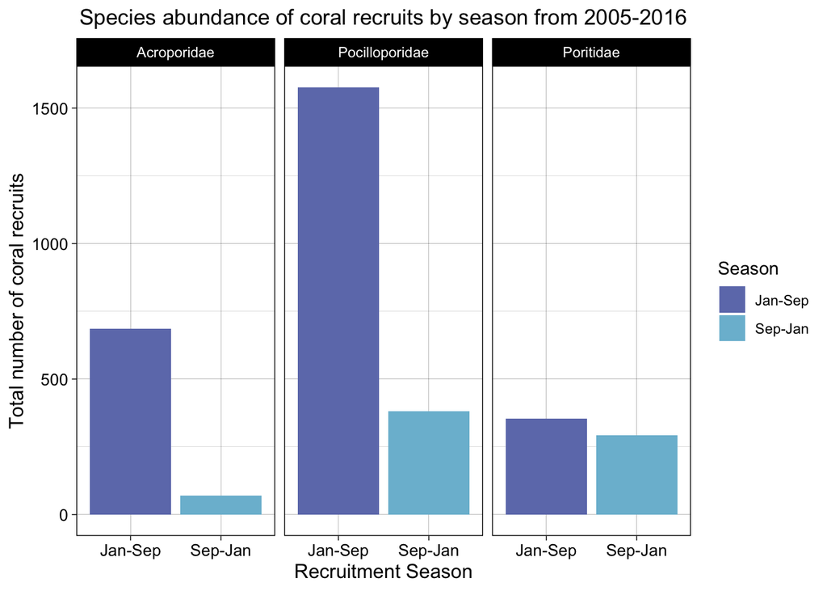

```r
ggplot(data=coral_counts_sum,
       aes(x=season,
           y=sum_total,
           fill=season)) +
  geom_col() +
  facet_wrap(~family) +
  theme_linedraw() +
  scale_fill_manual(values=pnw_palette("Sailboat")) + #love a good PNW color scheme
  labs(x="Recruitment Season",
       y="Total number of coral recruits",
       title="Species abundance of coral recruits by season from 2005-2016",
       fill="Season") +
  theme(axis.text.x=element_text(size=10),
        axis.text.y=element_text(size=10),
        axis.title.x=element_text(size=12),
        axis.title.y=element_text(size=12),
        plot.title=element_text(hjust=0.5))
```

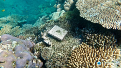

```r
ggsave(here("GoodPlot_BadPlot", "Output", "goodplot_recruitment.jpg"),
       width=6, height=5)

##This plot includes a picture of recruitment tiles to give context for the data.
??magick
tiles <-image_read("http://www.australiangeographic.com.au/wp-content/uploads/2019/04/Settlement-on-tile-900x507.jpg")

recruit <- image_read(here("GoodPlot_BadPlot", "Output", "goodplot_recruitment.jpg"))

tiles2 <- image_scale(tiles, "250x350") ##figuring out how to crop the image so it is not as large
tiles2
```

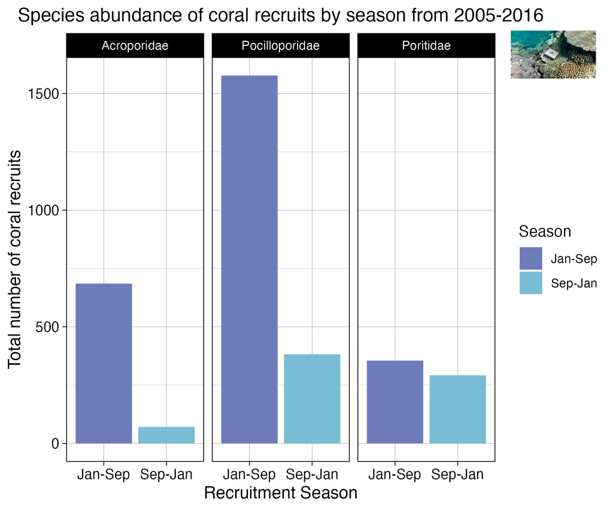

This plot shows the total counts from 2005-2016 for coral recruits on collected tiles across all habitats and shores. Image in top right corner shows what a coral recruitment tile looks like in situ.

```r
goodplot_tileimage <- image_composite(recruit, tiles2, offset = "+1500+90") #adding two images to each other and offset is used to move the picture around the frame --> first number is the width and second is height
goodplot_tileimage
```

## Make a bad plot

This is a bad plot because … well hopefully it is obvious.  
Following Healy’s three categories of what makes a bad plot (aesthetic, substantive, and perceptual), this plot includes a little of all three. Aside from the obvious **bold** choice of colors, the axis labels are too big to read effectively and the title is small and off-center. In terms of substantive data portrayal, the actual data is facet wrapped in such a way that no context is really given for what we are looking at. There is count data on the y axis, but for what? And there is virtually no context given for what or where these lagoon or forereef areas are. Also, the axes are scaled inappropriately (how would there be negative recruits?), which skews the perception of the results. It puts the data crunched in the middle of the graph. The line shapes are also too crowded together to actually see the data.

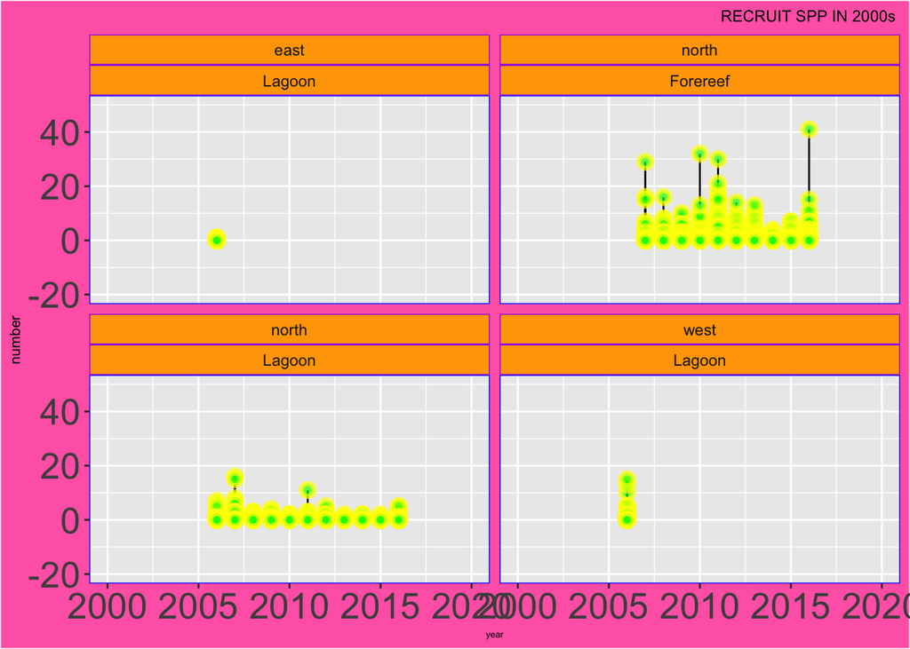

This is a really bad plot that illustrates the counts of coral families (unlabeled) on recruitment tiles in different habitats and shores in Moorea from 2005-2016

```r
ggplot(data=coral_counts,
       aes(x=nominal_year,
           y=count)) +
  geom_segment(aes(x=nominal_year, xend=nominal_year, y=0, yend=count)) +
  geom_point(size=2, color="yellow", fill=alpha("green", 0.1), alpha=0.7, shape=21, stroke=2) +
  facet_wrap(shore~habitat) +
  theme_gray() +
  labs(x="year",
       y="number",
       title="RECRUIT SPP IN 2000s ") +
  theme(axis.text.x=element_text(size=20),
        axis.text.y=element_text(size=20),
        axis.title.x=element_text(size=5),
        axis.title.y=element_text(size=8),
        plot.title=element_text(hjust=1, size = rel(0.8) ),
        plot.background=element_rect("hotpink"),
        panel.border=element_rect(fill = NA, colour = "blue"),
        strip.background = element_rect(fill = "orange", colour = "purple")) +
  xlim(2000,2020) +
  ylim(-20,50) #changing the axes coordinates
```

```r
ggsave(here("GoodPlot_BadPlot","Output", "Bad_Plot.jpg"), height=10, width=10)
```

## Summary

- This assignment helped me learn different ways to manipulate a dataset as well as aesthetics for a plot. I think it would be cool to have figured out a way to insert and image of a recruitment tile and then somehow get the location of each recruit as a data point onto the image to better visualize the data. However, I think my plot does a good job at presenting the information in an understandable and relevant way, and my bad plot is confusing and harsh to look at, which fits the goals of the assignment.